# nba_statistical analysis

### density plot of the data

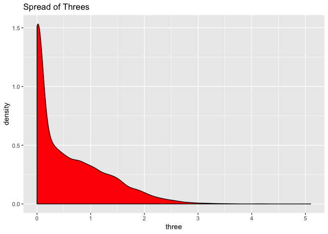

Threes are right skewed as expected since the best players take and make the most shots.

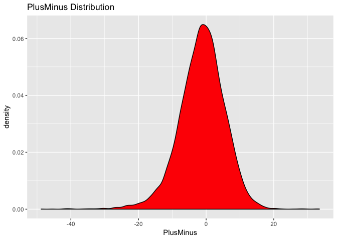

PlusMinus is more normal for the distribution.

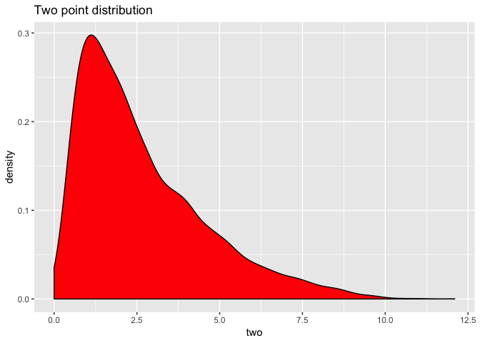

Two point scored is right skewed as well but not as right skewed as threepoint shots. It would be interesting to split the range of the two point shot from 2 ft and 15ft etc…

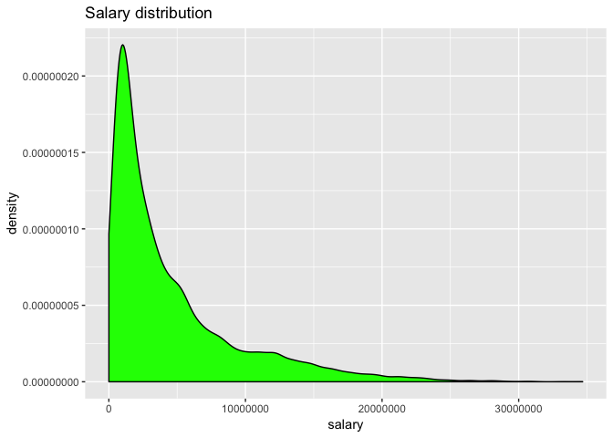

Salary distribution is right skewed as expected since the best players take the most money from the team. This is due to how the contracts are strucured where players who sign for the max take 25 percent to 40 percent of the teams salary.

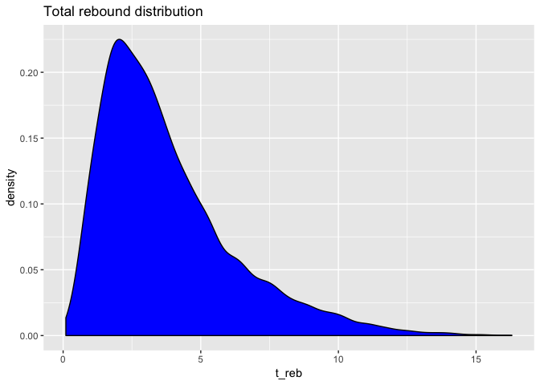

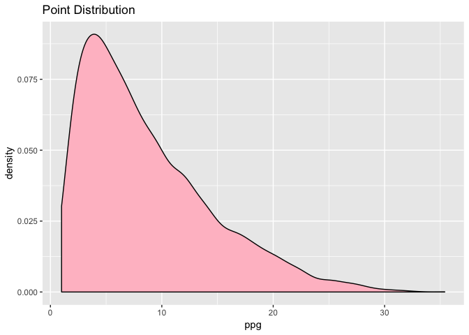

Total rebounds and PPG are also right skewed as more talented players or top players will score or grab more rebounds.

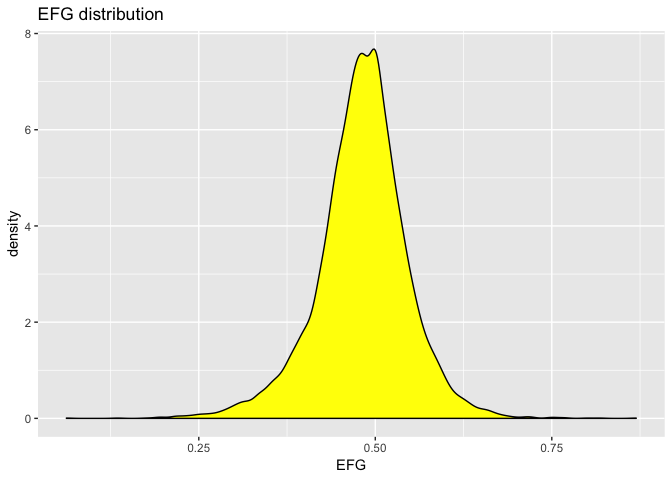

EFG looks to be normally distributed as it calculateds the effective field goal percentage for scoring stats.

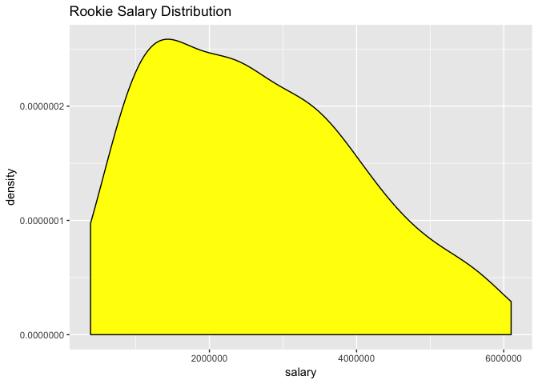

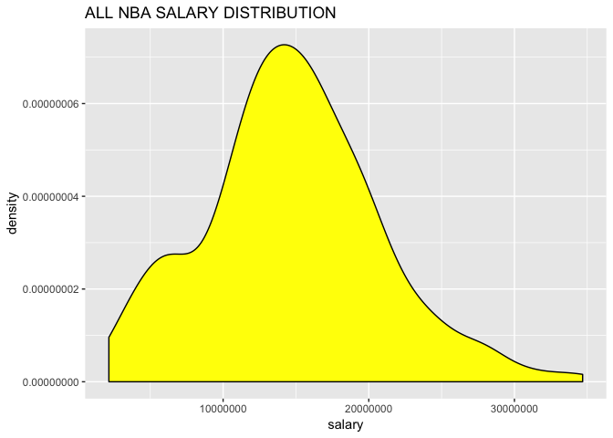

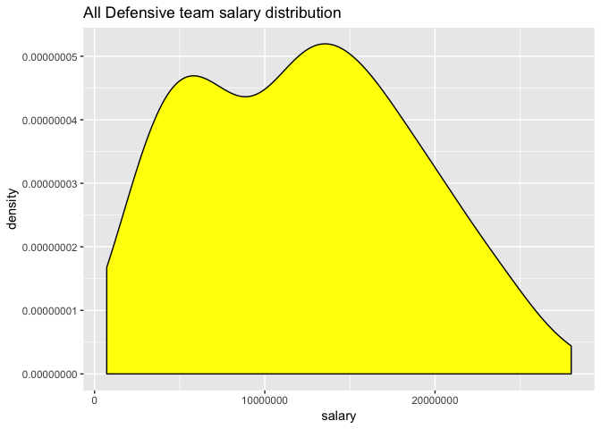

The distribution for defensive player of the year looks interesting as there seems to be a second hump forming for the density plot.

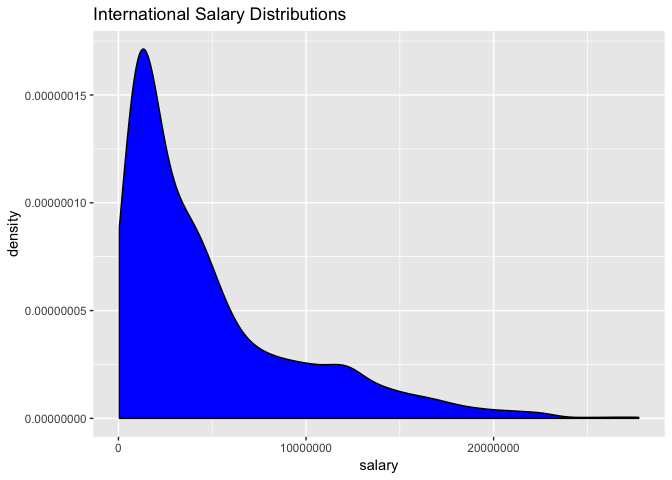

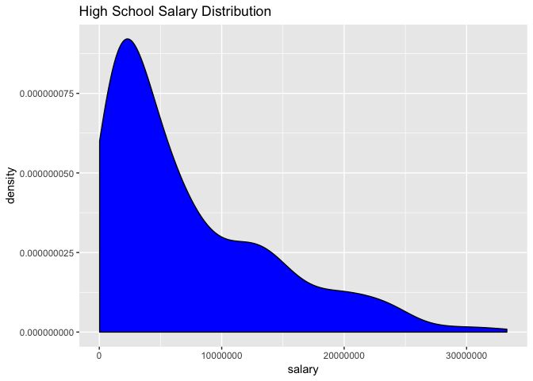

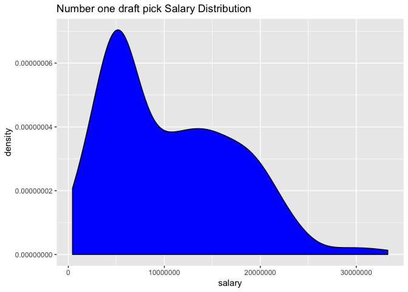

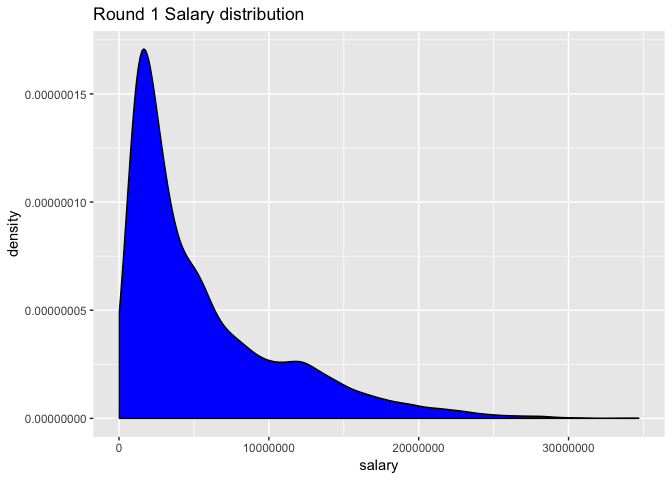

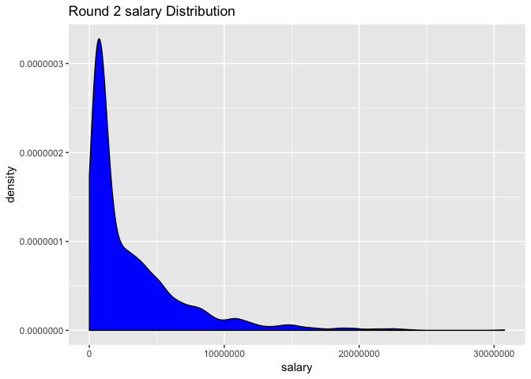

All the plots are right skewed. Round 2 is the most right skewed as its hard to find really gems in the second round who will be star players and command a higher salary.